# Classification

Ghson Alotibi

02/24/2025

**Abstract:**

This is a technical blog post of **both** an HTML file *and* [.qmd file](https://raw.githubusercontent.com/cd-public/D505/refs/heads/master/hws/src/classify.qmd) hosted on GitHub pages.

# 0. Quarto Type-setting

- This document is rendered with Quarto, and configured to embed an images using the `embed-resources` option in the header.
- If you wish to use a similar header, here’s is the format specification for this document:

`email: "gfalotibi@willamette.edu" format: html: embed-resources: true`

# 1. Setup

**Step Up Code:**

```r
sh <- suppressPackageStartupMessages
sh(library(tidyverse))
sh(library(caret))
sh(library(naivebayes))
sh(library(pROC)) # For ROC curves
sh(library(tidytext)) # For text processing
sh(library(SnowballC)) # For stemming

wine <- readRDS(gzcon(url("https://github.com/cd-public/D505/raw/master/dat/pinot.rds")))
```

# 2. Logistic Concepts

Why do we call it Logistic Regression even though we are using the technique for classification?

> TODO: *Logistic regression is called “regression” despite being used primarily for classification because it estimates the continuous probability of class membership rather than directly predicting discrete classes. The algorithm fits a regression model to the log-odds (logit) of the target variable, which follows a linear relationship with the predictors.*

$$log( p/1−p )=β0+β1 x1 + β2 x2 +...+βn xn$$

# 3. Modeling

We report Kappa after using the model to predict provinces in the holdout sample.

```r
# Text processing functions
desc_to_words <- function(df, omits) {
  df %>%
    unnest_tokens(word, description) %>%
    anti_join(stop_words) %>% # get rid of stop words
    filter(!(word %in% omits))
}

words_to_stems <- function(df) {
  df %>%
    mutate(word = wordStem(word))
}

filter_by_count <- function(df, j) {
  df %>%
    count(id, word) %>%
    group_by(id) %>% mutate(exists = (n>0)) %>% ungroup %>%
    group_by(word) %>%
    mutate(total = sum(n)) %>%
    filter(total > j)
}

pivoter <- function(words, df) {
  words %>%
    pivot_wider(id_cols = id, names_from = word, values_from = exists, values_fill = FALSE) %>%
    right_join(select(df, id, province)) %>%
    drop_na() %>%
    select(-id)
}

# Extract features from wine descriptions
words <- desc_to_words(wine, c("wine", "pinot", "vineyard"))
stems <- words_to_stems(words)
filtered_stems <- filter_by_count(stems, 100)

# Create feature matrix
wino <- pivoter(filtered_stems, wine)
# Create binary target variable for Marlborough
wino <- wino %>%
  mutate(marlborough = factor(province == "Marlborough")) %>%
  select(-province)

# Create train-test split
set.seed(123) # For reproducibility
wine_index <- createDataPartition(wino$marlborough, p = 0.80, list = FALSE)
train <- wino[wine_index, ]
test <- wino[-wine_index, ]

# Train logistic regression model with cross-validation
control <- trainControl(method = "cv", number = 5)
fit <- train(
  marlborough ~ .,
  data = train,
  trControl = control,
  method = "glm",
  family = "binomial"
)
# Evaluate on test set
pred <- predict(fit, newdata = test)
conf_matrix <- confusionMatrix(pred, test$marlborough)

# Display results
print(fit)
```

```
## Generalized Linear Model
##
## 6705 samples
##  358 predictor
##    2 classes: 'FALSE', 'TRUE'
##
## No pre-processing
## Resampling: Cross-Validated (5 fold)
## Summary of sample sizes: 5364, 5364, 5364, 5365, 5363
## Resampling results:
##
##   Accuracy   Kappa
##   0.9786727  0.6368813
```

```r
print(conf_matrix)
```

```
## Confusion Matrix and Statistics
##
##           Reference
## Prediction FALSE TRUE
##      FALSE  1611   12
##      TRUE     19   33
##
##                Accuracy : 0.9815
##                  95% CI : (0.9738, 0.9874)
##     No Information Rate : 0.9731
##     P-Value [Acc > NIR] : 0.01663
##
##                   Kappa : 0.6709
##
##  Mcnemar's Test P-Value : 0.28120
##
##             Sensitivity : 0.9883
##             Specificity : 0.7333
##          Pos Pred Value : 0.9926
##          Neg Pred Value : 0.6346
##              Prevalence : 0.9731
##          Detection Rate : 0.9618
##    Detection Prevalence : 0.9690
##       Balanced Accuracy : 0.8608
##
##        'Positive' Class : FALSE
##
```

```r
# Show top predictors
coef_summary <- summary(fit$finalModel)$coefficients
top_predictors <- coef_summary[order(-abs(coef_summary[,1])),][1:10,]
print(top_predictors)
```

```
##               Estimate Std. Error       z value  Pr(>|z|)
## detailTRUE   -70.77374   83300.02 -0.0008496246 0.9993221
## needlTRUE    -68.20158  103675.05 -0.0006578398 0.9994751
## mulberriTRUE -53.92276   95217.87 -0.0005663093 0.9995482
## olivTRUE     -52.27716  108568.94 -0.0004815113 0.9996158
## providTRUE   -49.57892  125159.28 -0.0003961266 0.9996839
## definTRUE    -48.02641   90163.08 -0.0005326616 0.9995750
## estatTRUE    -45.39408   70799.37 -0.0006411650 0.9994884
## warmTRUE     -43.53898  100081.17 -0.0004350367 0.9996529
## componTRUE   -42.18645   56862.81 -0.0007418988 0.9994081
## pommardTRUE  -41.81726  138975.17 -0.0003008974 0.9997599
```

# 4. Binary vs Other Classification

What is the difference between determining some form of classification through logistic regression versus methods like $K$-NN and Naive Bayes which performed classifications.

# 5. ROC Curves

We can display an ROC for the model to explain your model’s quality.

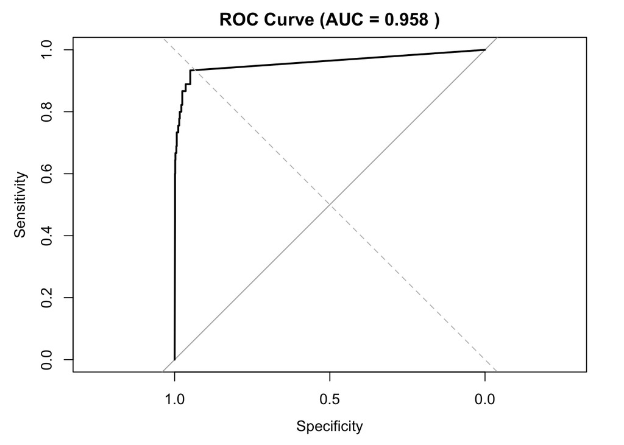

```r
# Generate predicted probabilities
prob <- predict(fit, newdata = test, type = "prob")[,2]

# Create ROC curve
roc_curve <- roc(test$marlborough, prob)
auc_value <- auc(roc_curve)

# Plot ROC curve
plot(roc_curve, main = paste("ROC Curve (AUC =", round(auc_value, 3), ")"))
abline(a = 0, b = 1, lty = 2, col = "gray")
```